# Tugas 7 MPDW

G1401211038_Dhiya Khalishah Tsany Suwarso

2023-10-15

### Packages

```r
library(ggplot2)
library(tsibble)
library(tseries)
library(MASS)
library(forecast)
library(TSA)
library(TTR)
library(aTSA)
library(graphics)
```

### Input Data yang akan digunakan

Data yang digunakan adalah Apple Stock Price mingguan dengan total 822 periode

```r
library(rio)
data <- import('https://raw.githubusercontent.com/dhiyakhalishah/PraktikumMPDW/main/appleStockPrice.csv')
data.ts <- ts(data$Harga_Mingguan)
```

### Eksplorasi Data

#### Plot Data Penuh

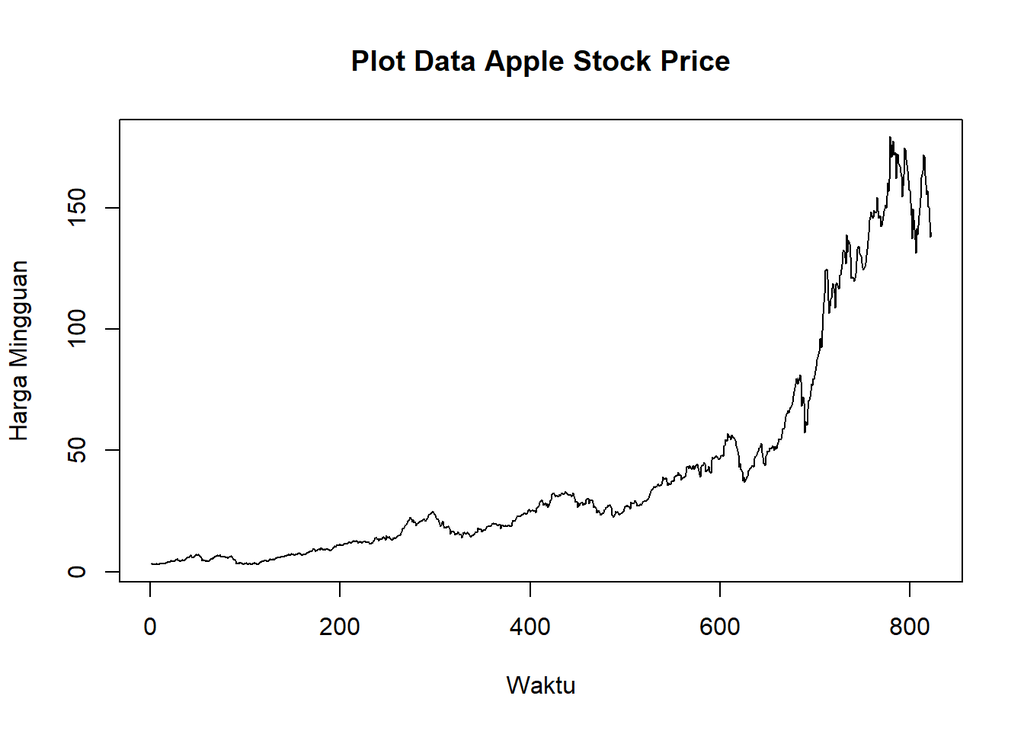

```r
plot.ts(data.ts, lty=1, xlab="Waktu", ylab="Harga Mingguan", main="Plot Data Apple Stock Price")
```

Berdasarkan plot data deret waktu, terlihat bahwa data cenderung memiliki trend yang naik. Berdasarkan pola data, pembagian data latih dan data uji ditetapkan dengan proporsi 80%:20% sehingga 658 periode untuk data latih dan 164 periode untuk data uji.

#### Plot Data Latih

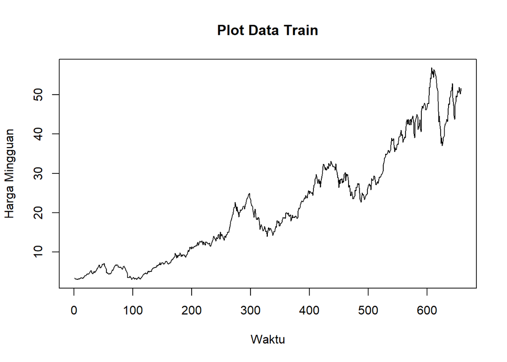

```r
datatrain<-data$Harga_Mingguan[1:658]
train.ts<-ts(datatrain)
plot.ts(train.ts, lty=1, xlab="Waktu", ylab="Harga Mingguan", main="Plot Data Train")
```

Berdasarkan plot data deret waktu pada data latih, terlihat bahwa data cenderung memiliki trend yang naik dan cenderung tidak bergerak pada nilai tengah tertentu. Hal ini mengindikasikan bahwa data tidak stasioner dalam rataan.

#### Plot Data Uji

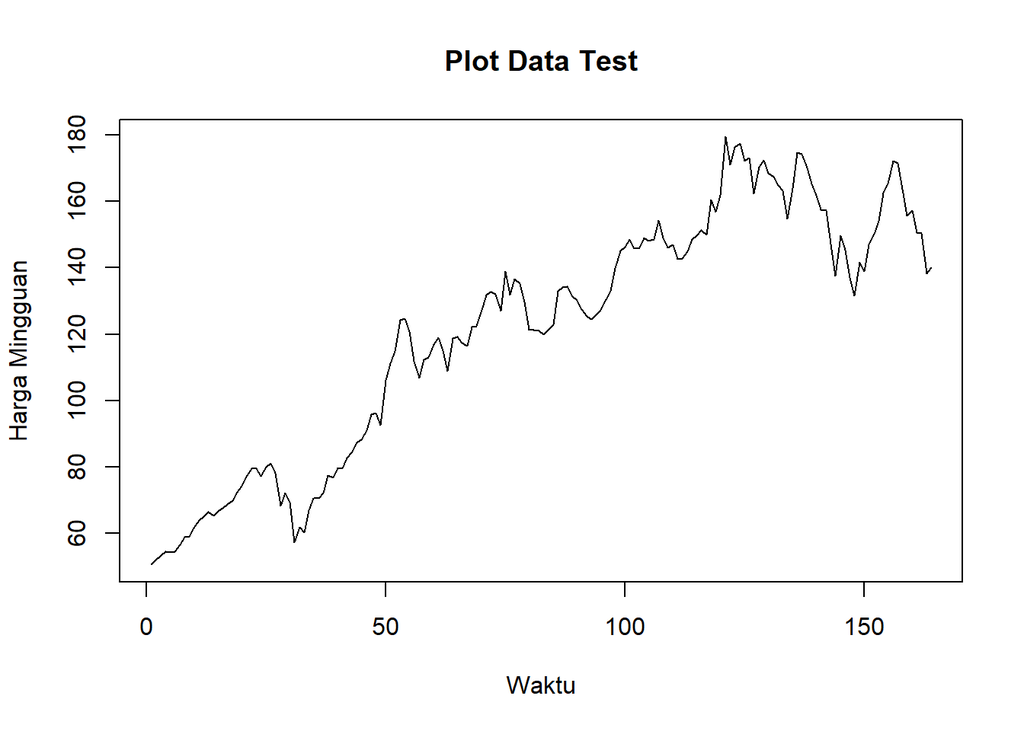

```r
datatest<-data$Harga_Mingguan[659:822]
test.ts<-ts(datatest)
plot.ts(test.ts, lty=1, xlab="Waktu", ylab="Harga Mingguan", main="Plot Data Test")
```

Berdasarkan plot data deret waktu pada data uji, terlihat bahwa data cenderung memiliki trend yang naik dan cenderung tidak bergerak pada nilai tengah tertentu. Hal ini mengindikasikan bahwa data tidak stasioner dalam rataan.

### Uji Stasioneritas Data

#### Plot ACF

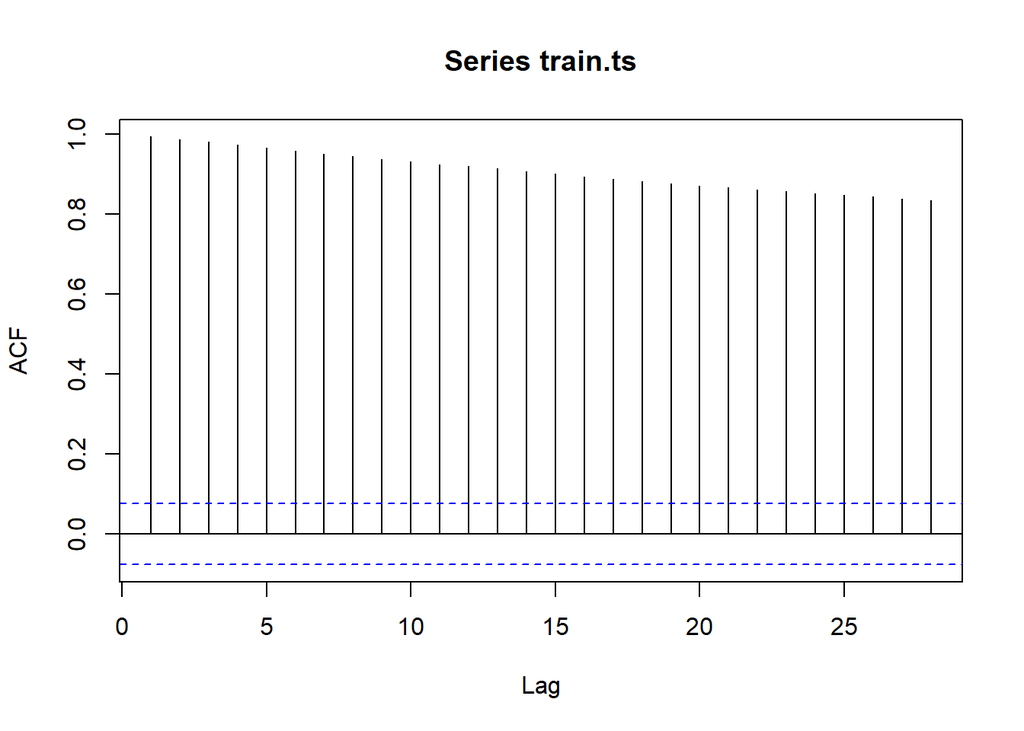

```r
acf(train.ts)
```

Berdasarkan plot ACF, terlihat bahwa plot ACF data menurun secara perlahan (*tails of slowly*). Hal ini juga menjadi indikasi bahwa data tidak stasioner dalam rataan.

#### Uji ADF

```r
tseries::adf.test(train.ts)
```

```
##
##  Augmented Dickey-Fuller Test
##
## data:  train.ts
## Dickey-Fuller = -2.8414, Lag order = 8, p-value = 0.2222
## alternative hypothesis: stationary
```

$H_0$ : Data tidak stasioner dalam rataan

$H_1$ : Data stasioner dalam rataan

Berdasarkan uji ADF tersebut, didapat *p-value* sebesar 0.2222 yang lebih besar dari taraf nyata 5% sehingga tak tolak $H_0$ dan menandakan bahwa data tidak stasioner dalam rataan. Hal ini sesuai dengan hasil eksplorasi menggunakan plot time series dan plot ACF, sehingga ketidakstasioneran model kedepannya harus ditangani.

#### Plot Box-Cox

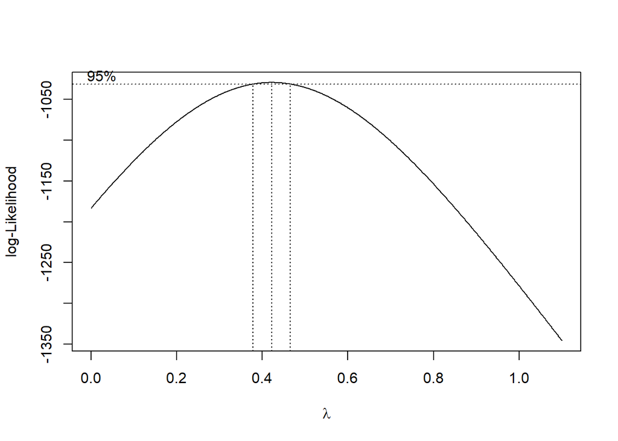

```r
index <- seq(1:658)
bc = boxcox(train.ts~index, lambda = seq(0,1.1,by=0.001))
```

```r
#Nilai Rounded Lambda
lambda <- bc$x[which.max(bc$y)]
lambda
```

```
## [1] 0.422
```

```r
#SK
bc$x[bc$y > max(bc$y) - 1/2 * qchisq(.95,1)]
```

```
##  [1] 0.379 0.380 0.381 0.382 0.383 0.384 0.385 0.386 0.387 0.388 0.389 0.390
## [13] 0.391 0.392 0.393 0.394 0.395 0.396 0.397 0.398 0.399 0.400 0.401 0.402
## [25] 0.403 0.404 0.405 0.406 0.407 0.408 0.409 0.410 0.411 0.412 0.413 0.414
## [37] 0.415 0.416 0.417 0.418 0.419 0.420 0.421 0.422 0.423 0.424 0.425 0.426
## [49] 0.427 0.428 0.429 0.430 0.431 0.432 0.433 0.434 0.435 0.436 0.437 0.438
## [61] 0.439 0.440 0.441 0.442 0.443 0.444 0.445 0.446 0.447 0.448 0.449 0.450
## [73] 0.451 0.452 0.453 0.454 0.455 0.456 0.457 0.458 0.459 0.460 0.461 0.462
## [85] 0.463 0.464 0.465
```

Plot Boxcox menunjukkan nilai *rounded value* ($\lambda$) optimum sebesar **0.422** dan pada selang kepercayaan 95% nilai memiliki batas bawah **0.379** dan batas atas **0.465**. Selang tersebut tidak memuat nilai satu sehingga dapat dikatakan bahwa data tidak stasioner dalam ragam.

### Penanganan Ketidakstasioneran Data

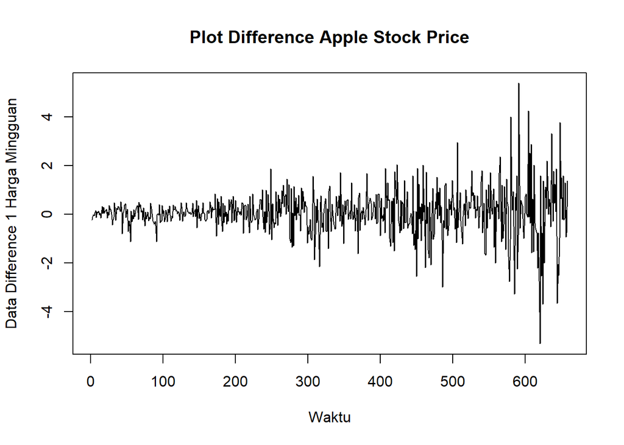

```r
train.diff<-diff(train.ts,differences = 1)
plot.ts(train.diff, lty=1, xlab="Waktu", ylab="Data Difference 1 Harga Mingguan", main="Plot Difference Apple Stock Price")
```

Berdasarkan plot data deret waktu, terlihat bahwa data sudah stasioner dalam rataan ditandai dengan data bergerak pada nilai tengah tertentu.

#### Plot ACF

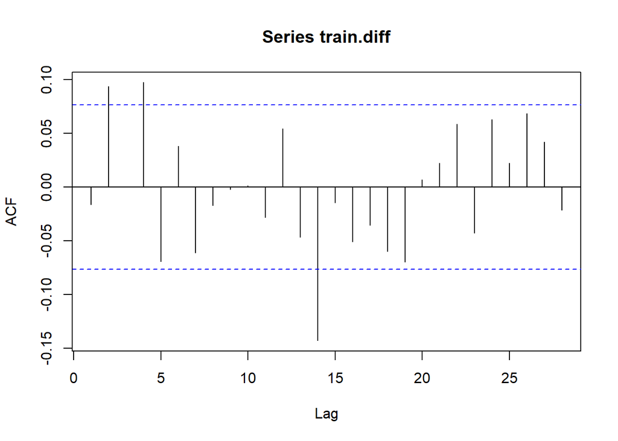

```r
acf(train.diff)
```

Berdasarkan plot tersebut, terlihat bahwa plot ACF cuts off pada lag ke 2. Hal ini menandakan data sudah stasioner dalam rataan dan ketidakstasioneran data telah berhasil tertangani.

#### Uji ADF

```r
tseries::adf.test(train.diff)
```

```
##
##  Augmented Dickey-Fuller Test
##
## data:  train.diff
## Dickey-Fuller = -8.5285, Lag order = 8, p-value = 0.01
## alternative hypothesis: stationary
```

$H_0$ : Data tidak stasioner dalam rataan

$H_1$ : Data stasioner dalam rataan

Berdasarkan uji ADF tersebut, didapat *p-value* sebesar 0.01 yang lebih kecil dari taraf nyata 5% sehingga tolak $H_0$ atau data stasioner dalam rataan. Hal ini sesuai dengan hasil eksplorasi menggunakan plot time series dan plot ACF, sehingga dalam hal ini ketidakstasioneran data sudah berhasil ditangani dan dapat dilanjutkan ke pemodelan

### Identifikasi Model

#### Plot ACF

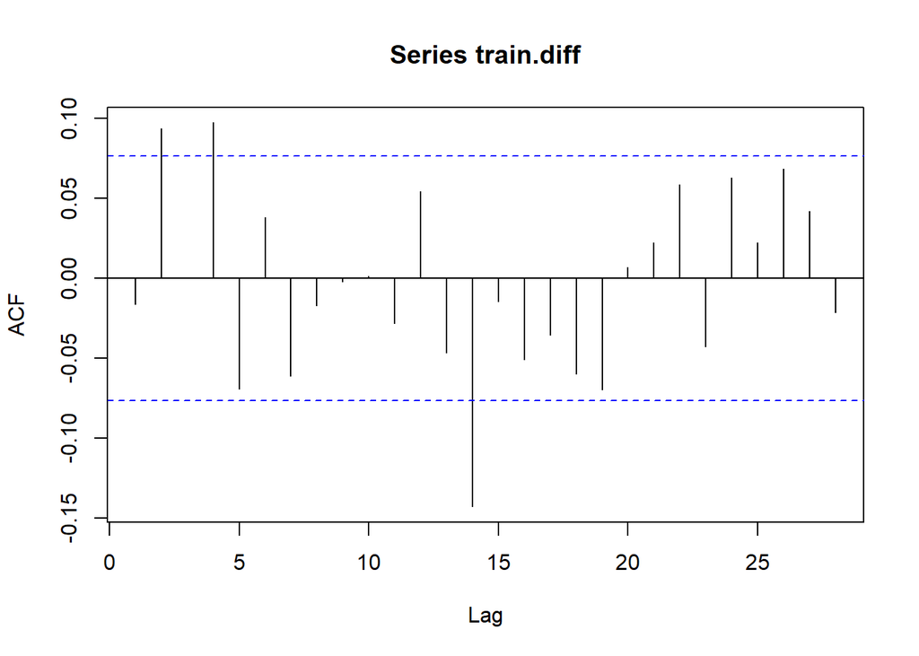

```r
acf(train.diff)
```

Berdasarkan plot tersebut, terlihat bahwa plot ACF cenderung *cuts off* pada lag ke 2, sehingga jika plot PACF dianggap *tails off*, maka model tentatifnya adalah ARIMA(0,1,2).

#### Plot PACF

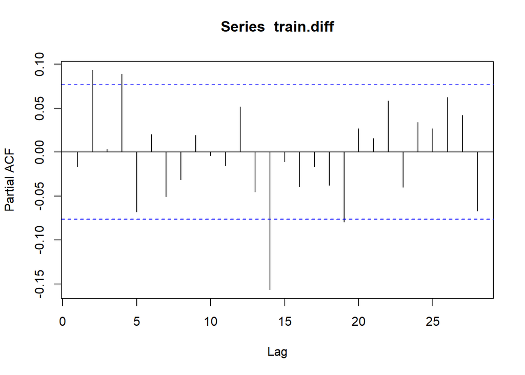

```r
pacf(train.diff)
```

Berdasarkan plot tersebut, terlihat bahwa plot PACF cenderung *cuts off* pada lag ke 2, sehingga jika plot ACF dianggap *tails off*, maka model tentatifnya adalah ARIMA(2,1,0).

Jika baik plot ACF maupun plot PACF keduanya dianggap tails off, maka model yang terbentuk adalah ARIMA(2,1,2)

#### Plot EACF

```r
eacf(train.diff)
```

```
## AR/MA
##   0 1 2 3 4 5 6 7 8 9 10 11 12 13
## 0 o x o x o o o o o o o  o  o  x
## 1 x x o o o o o o o o o  o  o  x
## 2 o x o o o o o o o o o  o  o  x
## 3 o x x o o o o o o o o  o  o  x
## 4 x x x x o o x o o o o  o  o  x
## 5 x x o x x o o o o o o  o  o  x
## 6 x x o x x x o o o o o  o  o  x
## 7 x x x o x x o o o o o  o  o  x
```

Identifikasi model menggunakan plot EACF dilakukan dengan melihat ujung segitiga pada pola segitiga nol. Dalam hal ini model tentatif yang terbentuk adalah ARIMA(0,1,2), ARIMA(2,1,0), ARIMA(2,1,2), dan ARIMA(1,1,2), ARIMA(0,1,4).

### Pendugaan Parameter Model Tentatif

#### ARIMA(0,1,2)

```r
model1.da=Arima(train.diff, order=c(0,1,2),method="ML")
summary(model1.da) #AIC=1755.17
```

```
## Series: train.diff
## ARIMA(0,1,2)
##
## Coefficients:
##           ma1     ma2
##       -1.0126  0.0126
## s.e.   0.0364  0.0358
##
## sigma^2 = 0.8367:  log likelihood = -874.59
## AIC=1755.17   AICc=1755.21   BIC=1768.63
##
## Training set error measures:
##                      ME      RMSE       MAE      MPE     MAPE      MASE
## Training set 0.02908763 0.9126031 0.6014453 99.34079 137.5846 0.6884442
##                      ACF1
## Training set -0.003574039
```

```r
lmtest::coeftest(model1.da) #terdapat parameter tidak signifikan
```

```
##
## z test of coefficients:
##
##      Estimate Std. Error  z value Pr(>|z|)
## ma1 -1.012638   0.036356 -27.8530   <2e-16 ***
## ma2  0.012638   0.035835   0.3527   0.7243
## ---
## Signif. codes:  0 '***' 0.001 '**' 0.01 '*' 0.05 '.' 0.1 ' ' 1
```

#### ARIMA(2,1,0)

```r
model2.da=Arima(train.diff, order=c(2,1,0),method="ML")
summary(model2.da) #AIC=1912.44
```

```
## Series: train.diff
## ARIMA(2,1,0)
##
## Coefficients:
##           ar1      ar2
##       -0.7199  -0.2985
## s.e.   0.0374   0.0373
##
## sigma^2 = 1.073:  log likelihood = -953.22
## AIC=1912.44   AICc=1912.48   BIC=1925.9
##
## Training set error measures:
##                       ME     RMSE       MAE      MPE     MAPE      MASE
## Training set 0.001444397 1.033506 0.6878084 249.0643 611.3512 0.7872997
##                     ACF1
## Training set -0.08907746
```

```r
lmtest::coeftest(model2.da) #seluruh parameter signifikan
```

```
##
## z test of coefficients:
##
##      Estimate Std. Error  z value  Pr(>|z|)
## ar1 -0.719889   0.037372 -19.2631 < 2.2e-16 ***
## ar2 -0.298527   0.037329  -7.9972 1.273e-15 ***
## ---
## Signif. codes:  0 '***' 0.001 '**' 0.01 '*' 0.05 '.' 0.1 ' ' 1
```

#### ARIMA(2,1,2)

```r
model3.da=Arima(train.diff, order=c(2,1,2),method="ML")
summary(model3.da) #AIC=1749.64
```

```
## Series: train.diff
## ARIMA(2,1,2)
##
## Coefficients:
##           ar1     ar2      ma1      ma2
##       -0.7448  0.0702  -0.2581  -0.7419
## s.e.   0.1310  0.0431   0.1266   0.1266
##
## sigma^2 = 0.8272:  log likelihood = -869.82
## AIC=1749.64   AICc=1749.73   BIC=1772.07
##
## Training set error measures:
##                      ME      RMSE       MAE      MPE     MAPE      MASE
## Training set 0.02783901 0.9060339 0.5952157 122.6201 184.6084 0.6813135
##                      ACF1
## Training set -0.003623969
```

```r
lmtest::coeftest(model3.da) #terdapat parameter tidak signifikan
```

```
##
## z test of coefficients:
##
##      Estimate Std. Error z value  Pr(>|z|)
## ar1 -0.744791   0.131024 -5.6844 1.313e-08 ***
## ar2  0.070173   0.043082  1.6288   0.10335
## ma1 -0.258140   0.126641 -2.0384   0.04151 *
## ma2 -0.741860   0.126579 -5.8608 4.605e-09 ***
## ---
## Signif. codes:  0 '***' 0.001 '**' 0.01 '*' 0.05 '.' 0.1 ' ' 1
```